# Tugas-Pertemuan-4

# 1. MA(2) – Moving Average

## a. Pembangkitan Manual

Kode membangkitkan 300 data *white noise* dan kemudian membentuk MA(2) dengan

$$Y_t = e_t + 0.4e_{t-1} +
0.6e_{t-2}$$

Loop dimulai dari $i=3$ karena untuk menghitung $Y_t$ dibutuhkan $e_{t-1}$ dan $e_{t-2}$.

```r
set.seed(1234)

n <- 300
wn <- rnorm(n)

ma2 <- c(1:n)

for (i in 3:n) {
  ma2[i] <- wn[i] + 0.4*wn[i-1] + 0.6*wn[i-2]
}

ma2
```

```
##   [1]  1.000000000  2.000000000  0.471173424 -1.745463687  0.141510314
##   [6] -0.729712854 -0.114842790 -0.472894305 -1.127948717 -1.443797742
##  [11] -1.171879031 -1.723286222 -1.461924092 -0.845074607  0.519525249
##  [16]  0.312187420  0.020572732 -1.181770516 -1.508255550  1.534249256
##  [21]  0.598119283  1.012450498 -0.556369299 -0.011041246 -0.774213194
##  [26] -1.449939345 -0.420758391 -1.662676381 -0.079747157 -1.556197355
##  [31]  0.718835126 -0.596243221 -0.238298741 -1.070389923 -2.255260716
##  [36] -2.120011486 -3.624543435 -2.913580609 -2.138714925 -1.388210999
##  [41]  1.086560934 -0.768382742 -0.413123964 -1.263954490 -1.619808057
##  [46] -1.534624150 -2.091327966 -2.276021753 -1.689013389 -1.457572736
##  [51] -2.319068111 -1.602598402 -2.425338748 -1.807763414 -1.233628102
##  [56] -0.110845196  1.775654086  0.223607057  2.285258743 -0.979456751
##  [61]  1.157010823  2.116941328  1.378789117  0.845856907 -0.296314421
##  [66]  1.372262398 -0.432336811  1.978634754  1.193531021  1.688995021
##  [71]  0.939220832 -0.250827924 -0.544575725  0.228395751  2.109671129
```

[output cut: 45 more lines]

Hasil pembangkitan menghasilkan 300 pengamatan MA(2). Nilai $Y_t$ berfluktuasi di sekitar nilai tengah tanpa pola deterministik yang terlihat. Setiap nilai dipengaruhi oleh *white noise* pada waktu sekarang serta dua waktu sebelumnya melalui koefisien 0.4 dan 0.6.

## b. Dengan `arima.sim()`

`arima.sim()` digunakan untuk membangkitkan MA(2) dengan orde (0,0,2) dan koefisien MA 0.4 dan 0.6. Hasilnya juga terdiri dari 300 pengamatan.

```r
ma2.sim <- arima.sim(
  list(order = c(0,0,2), ma = c(0.4,0.6)),
  n = 300
)

ma2.sim
```

```
## Time Series:
## Start = 1
## End = 300
## Frequency = 1
##   [1] -0.908714261  0.366069559  0.319892749 -0.033692645 -0.749809541
##   [6]  1.023224875 -0.103827746  1.553027734  1.508813504  1.490258435
##  [11]  0.638775303  0.057508568 -0.761313741  1.006804154  0.046165301
##  [16]  2.226792228 -0.031351321  0.058227766 -0.452682262 -0.306828839
##  [21] -0.408896770 -1.768664231 -0.905163217 -1.653388217  0.814020129
##  [26] -0.949587092  1.394975120 -0.770061199  0.708742509  0.626264945
##  [31]  0.016220780  0.886163244 -0.177443664 -0.837739266 -0.776948985
##  [36]  0.830630275  0.271737011  0.068438994 -0.509614613 -0.182137038
##  [41]  1.054967504  1.724174690  1.131301118  1.891160132 -0.238116411
##  [46] -1.951472236 -1.868044756 -2.111236903 -2.805388403 -0.673455997
##  [51] -1.948408128 -0.202080988 -2.147789666 -0.222949385  1.157974906
```

[output cut: 49 more lines]

Hasil `arima.sim()` menghasilkan deret MA(2) sebanyak 300 pengamatan dengan spesifikasi model yang sama seperti pembangkitan manual. Nilai pengamatan menunjukkan fluktuasi acak di sekitar nilai tengah sehingga secara umum hasil simulasi telah menggambarkan karakteristik proses MA(2).

## c. Plot Time Series

Digunakan untuk melihat pola $Y_t$ sepanjang waktu.

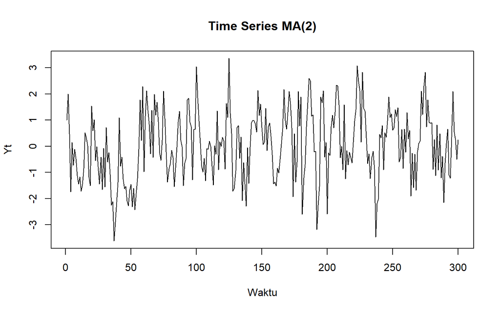

```r
plot.ts(ma2,
        main = "Time Series MA(2)",
        ylab = "Yt",
        xlab = "Waktu")
```

Plot time series MA(2) menunjukkan bahwa data berfluktuasi di sekitar nilai tengah tanpa adanya tren naik atau turun yang sistematis. Ragam data juga relatif konstan sepanjang waktu. Hal ini menunjukkan karakteristik deret yang stasioner.

## d. Plot ACF

ACF digunakan untuk melihat hubungan antara $Y_t$ dengan pengamatan pada beberapa lag.

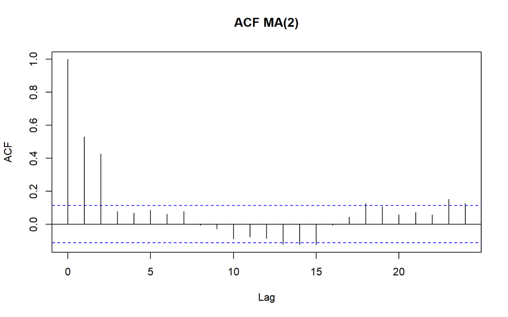

```r
acf(ma2,
    main = "ACF MA(2)")
```

Plot ACF MA(2) menunjukkan korelasi positif pada lag 1 dan lag 2, kemudian korelasi turun dan mendekati nol pada lag berikutnya. Pola ini sesuai dengan karakteristik teoritis MA(2), yaitu autokorelasi hanya muncul sampai lag ke-2 dan terputus setelahnya (*cut off*).

## e. Plot PACF

PACF digunakan untuk melihat korelasi parsial pada setiap lag setelah pengaruh lag di antaranya diperhitungkan.

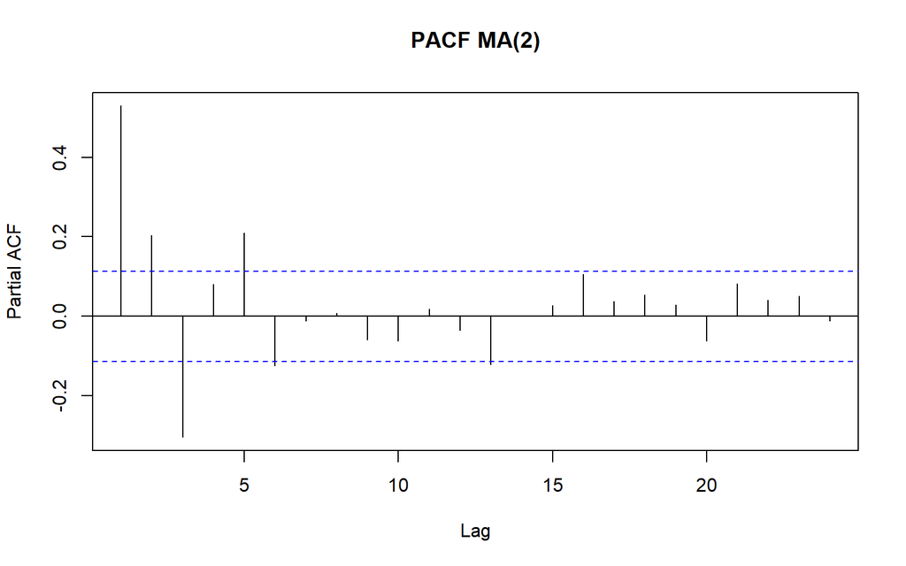

```r
pacf(ma2,
     main = "PACF MA(2)")
```

Plot PACF MA(2) menunjukkan pola yang menurun secara bertahap (*tails off*) dan tidak terputus secara tegas pada lag tertentu. Pola ini sesuai dengan karakteristik proses MA, yaitu PACF cenderung mengalami peluruhan secara bertahap.

## f. Plot EACF

EACF digunakan untuk membantu mengidentifikasi orde MA dan AR berdasarkan pola tanda pada tabel EACF.

```r
TSA::eacf(ma2)
```

```
## AR/MA
##   0 1 2 3 4 5 6 7 8 9 10 11 12 13
## 0 x x o o o o o o o o o  o  x  x
## 1 x x x o o o o o o o o  o  o  o
## 2 x x x x o o o o o o o  o  o  o
## 3 x x x x o o o o o o o  o  o  o
## 4 x x x x x o o o o o o  o  o  o
## 5 x x x x x o x o o o o  o  o  o
## 6 x o x o x x o x o o o  o  o  o
## 7 x o x o x o o x o o o  o  o  o
```

Hasil EACF menunjukkan pola yang dapat digunakan untuk mengidentifikasi model dengan komponen MA. Pola tersebut mendukung dugaan bahwa data memiliki komponen MA dengan orde 2.

## g. Stasioneritas

> Data hasil pembangkitan MA(2) dapat dikatakan stasioner karena plot time series tidak menunjukkan adanya tren maupun perubahan ragam yang sistematis sepanjang waktu. Selain itu, secara teori proses MA dengan orde hingga merupakan proses stasioner.

## h. Scatterplot $Y_t$ dengan $Y_{t−1}$

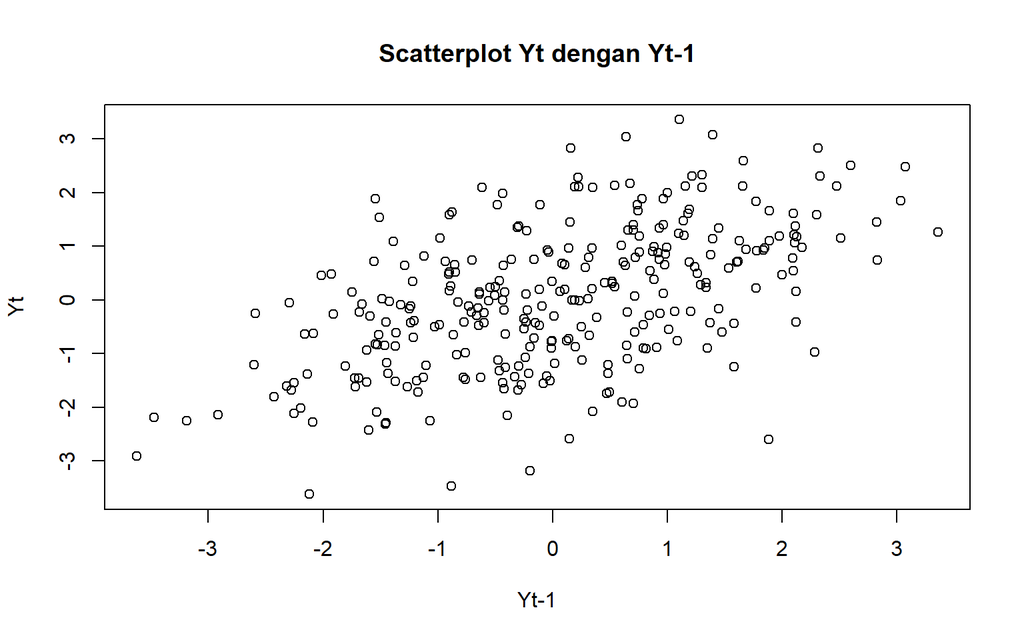

```r
# Yt
yt_ma2 <- ma2[-1]

# Yt-1
yt_1_ma2 <- ma2[-300]

plot(y = yt_ma2,
     x = yt_1_ma2,
     main = "Scatterplot Yt dengan Yt-1",
     xlab = "Yt-1",
     ylab = "Yt")
```

```r
cor(yt_ma2, yt_1_ma2)
```

```
## [1] 0.529629
```

> Scatterplot menunjukkan hubungan positif antara $Y_t$ dan $Y_{t-1}$, dengan korelasi simulasi sebesar **0.5296**. Hubungan ini menunjukkan bahwa nilai $Y_t$ cenderung meningkat ketika nilai pada satu periode sebelumnya meningkat.

Korelasi antara $Y_t$ dengan $Y_{t−1}$ dari hasil simulasi mendekati perhitungan teoritis, yaitu:

$$\rho_1=\frac{\theta_1+\theta_1\theta_2}{1+\theta_1^2+\theta_2^2}
=\frac{0.4+(0.4)(0.6)}{1+(0.4)^2+(0.6)^2}
=0.4211$$

## i. Scatterplot $Y_t$ dengan $Y_{t−2}$

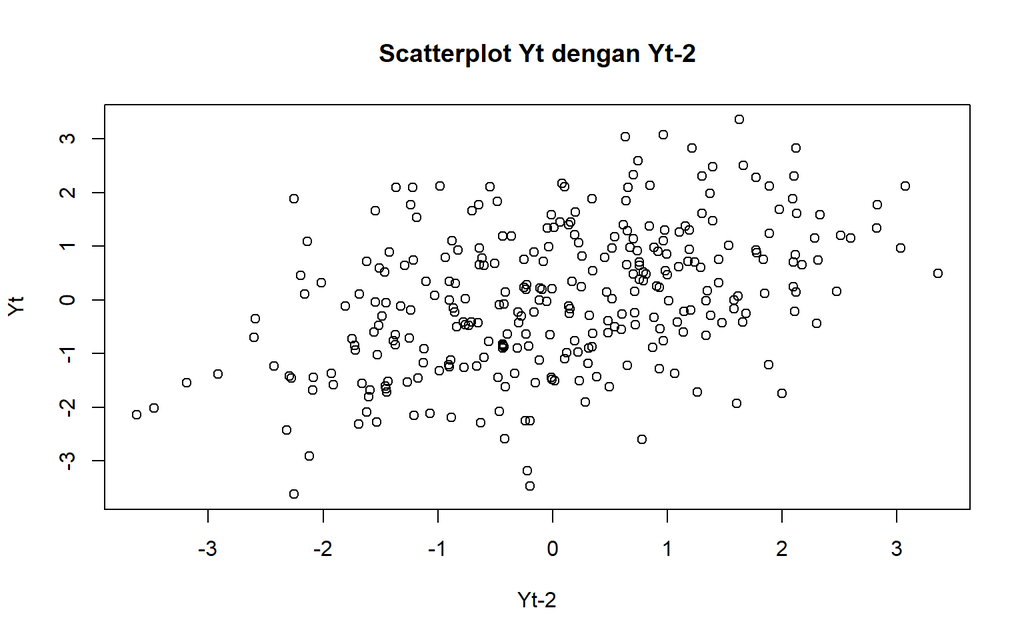

```r
# Yt
yt_ma2_2 <- ma2[-c(1,2)]

# Yt-2
yt_2_ma2 <- ma2[-c(299,300)]

plot(y = yt_ma2_2,
     x = yt_2_ma2,
     main = "Scatterplot Yt dengan Yt-2",
     xlab = "Yt-2",
     ylab = "Yt")
```

```r
cor(yt_ma2_2, yt_2_ma2)
```

```
## [1] 0.428484
```

> Pada lag 2, hubungan antara $Y_t$ dan $Y_{t-2}$ masih terlihat positif, dengan korelasi simulasi sebesar **0.4285**. Nilai korelasi yang lebih rendah dibandingkan lag 1 menunjukkan bahwa hubungan antar pengamatan mulai melemah ketika jarak lag bertambah.

Korelasi antara $Y_t$ dengan $Y_{t−2}$ dari hasil simulasi mendekati perhitungan teoritis, yaitu:

$$\rho_2=\frac{\theta_2}{1+\theta_1^2+\theta_2^2}
=\frac{0.6}{1+(0.4)^2+(0.6)^2}
=0.3947$$

## j. Scatterplot $Y_t$ dengan $Y_{t-3}$

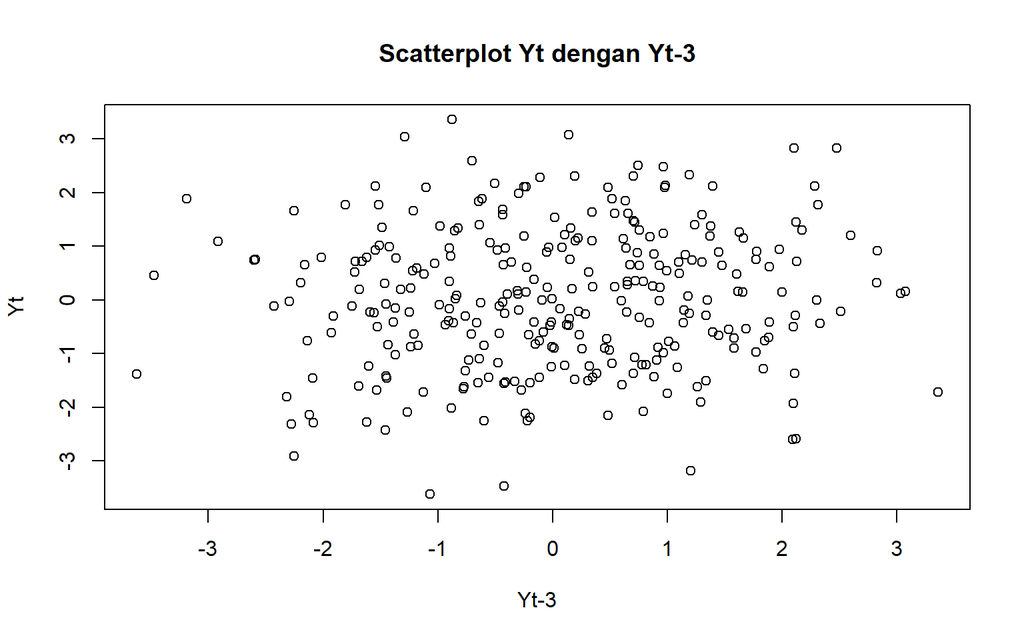

```r
# Yt
yt_ma2_3 <- ma2[-c(1,2,3)]

# Yt-3
yt_3_ma2 <- ma2[-c(298,299,300)]

plot(y = yt_ma2_3,
     x = yt_3_ma2,
     main = "Scatterplot Yt dengan Yt-3",
     xlab = "Yt-3",
     ylab = "Yt")
```

```r
cor(yt_ma2_3, yt_3_ma2)
```

```
## [1] 0.07798615
```

> Memasuki lag 3, korelasi simulasi turun menjadi **0.0780**, sehingga hubungan antara $Y_t$ dan $Y_{t-3}$ tergolong sangat lemah. Pola ini menunjukkan bahwa ketergantungan antar pengamatan hampir tidak terlihat setelah lag ke-2, sesuai dengan karakteristik **MA(2)** yang secara teoritis memiliki autokorelasi nol pada lag lebih dari 2.

Korelasi antara $Y_t$ dengan $Y_{t−3}$ hasil simulasi mendekati teori yang ada yaitu 0.

$$\rho_3=0$$

# 2. AR(2) –Autoregressive

## a. Pembangkitan Manual

Model yang digunakan adalah

$$Y_t = e_t + 0.5Y_{t-1} +
0.2Y_{t-2}$$

Jadi berbeda dengan MA(2), nilai sekarang dipengaruhi langsung oleh **nilai Y sebelumnya**, bukan hanya *white noise* sebelumnya.

```r
set.seed(1234)

n <- 300
wn <- rnorm(n)

ar2 <- c(1:n)

for (i in 3:n) {
  ar2[i] <- wn[i] + 0.5*ar2[i-1] + 0.2*ar2[i-2]
}

ar2
```

```
##   [1]  1.000000000  2.000000000  2.284441177 -0.803477114  0.484274367
##   [6]  0.587497653 -0.184136260 -0.521200455 -0.861879479 -1.425217660
##  [11] -1.362177425 -1.964518689 -2.030948724 -1.343919283 -0.118655327
##  [16] -0.438397015 -0.753939079 -1.375844359 -1.675881675  1.302725469
##  [21]  0.450274620 -0.005003493 -0.352994695  0.282091395 -0.623273488
##  [26] -1.703423376 -0.401610665 -1.565145730 -0.878033298 -1.687994396
##  [31]  0.082693688 -0.771845114 -1.078823857 -1.195039012 -2.442377746
##  [36] -2.627815938 -3.982423167 -3.857767963 -3.019662474 -2.747282370
##  [41] -0.528077414 -1.882137905 -1.902049069 -1.608075117 -2.178787449
##  [46] -2.379523066 -2.732837215 -3.094309106 -2.617550115 -2.424486836
##  [51] -3.541784698 -2.837865641 -3.236179384 -3.200624830 -2.409857815
##  [56] -1.281998055  0.524846882 -0.767329594  1.327214208 -0.647667362
##  [61]  0.598197625  2.718556411  1.444157341  0.596156373  0.579304899
##  [66]  2.185968172  0.070237329  1.840139478  2.263681996  1.836341691
##  [71]  1.377800083  0.600699641  0.209385904  0.873119448  2.548707766
```

[output cut: 45 more lines]

Hasil pembangkitan menghasilkan 300 pengamatan AR(2). Nilai $Y_t$ dibentuk dari *white noise* pada waktu sekarang serta dua pengamatan sebelumnya dengan koefisien masing-masing 0.5 dan 0.2. Oleh karena itu, nilai pengamatan cenderung memiliki ketergantungan terhadap nilai pada periode sebelumnya.

## b. Dengan `arima.sim()`

```r
ar2.sim <- arima.sim(
  list(order = c(2,0,0), ar = c(0.5,0.2)),
  n = 300
)

ar2.sim
```

```
## Time Series:
## Start = 1
## End = 300
## Frequency = 1
##   [1] -1.51198789  0.14622636 -1.18196985  0.56474307 -0.60306545  0.10388597
##   [7]  0.83003262 -0.08294885  0.67897065  0.23492188 -0.88195786 -0.66407416
##  [13]  1.11136122  0.20873461 -0.49114292 -0.25784746  0.10298930  0.95524977
##  [19]  1.64218262  1.11266366  2.04934360  0.48294459 -1.69317239 -1.22168070
##  [25] -1.46533032 -3.29303745 -1.37711303 -2.13093915 -1.56694617 -2.79676390
##  [31] -1.16424698  0.74975075 -0.73605113 -0.33063433  1.63618567  1.68578230
##  [37]  3.08318771  1.87351626  1.40113562  0.56563940  1.99762053 -0.17390039
##  [43]  0.61988813  0.22884545  2.49024215  0.68285644 -0.66981152  0.03429730
##  [49] -0.15646235 -0.91049678 -0.35424977 -0.63474899 -1.06698309 -0.15960541
##  [55] -0.62486164 -2.17933215 -3.86637965 -2.94963843 -0.79390827 -0.14875244
##  [61]  0.98189570  1.44370281  1.23399457 -0.60132478  0.15170631  1.55281629
```

[output cut: 39 more lines]

Hasil `arima.sim()` menghasilkan 300 pengamatan dengan spesifikasi AR(2) yang sama, yaitu koefisien AR sebesar 0.5 dan 0.2. Hasil simulasi menunjukkan adanya ketergantungan antarpengamatan yang terbentuk melalui dua lag sebelumnya.

## c. Plot Time Series

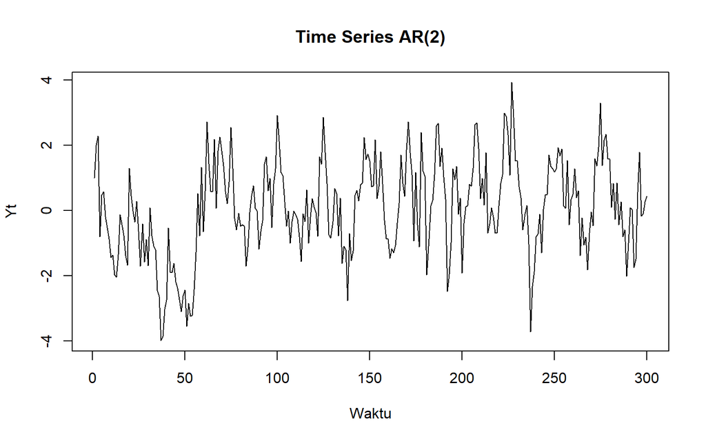

```r
plot.ts(ar2,
        main = "Time Series AR(2)",
        ylab = "Yt",
        xlab = "Waktu")
```

Plot time series AR(2) menunjukkan fluktuasi nilai sepanjang waktu tanpa pola tren yang sistematis. Meskipun terdapat rangkaian nilai yang cenderung bergerak searah pada beberapa periode, data tetap berfluktuasi di sekitar nilai tengah sehingga tidak menunjukkan pola nonstasioner yang jelas.

## d. Plot ACF

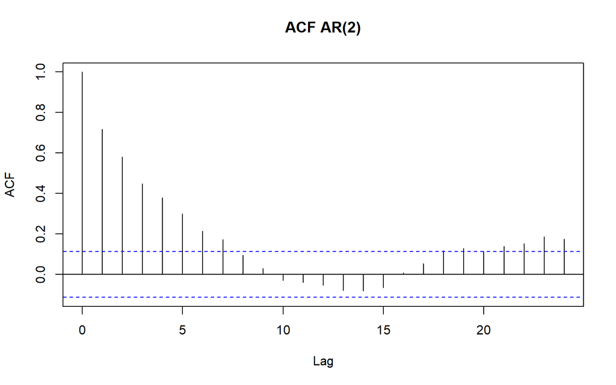

```r
acf(ar2,
    main = "ACF AR(2)")
```

Plot ACF AR(2) menunjukkan korelasi positif yang cukup kuat pada beberapa lag awal dan kemudian menurun secara bertahap. Pola *tails off* ini merupakan karakteristik proses AR, sehingga berbeda dengan MA(2) yang memiliki ACF terputus setelah lag ke-2.

## e. Plot PACF

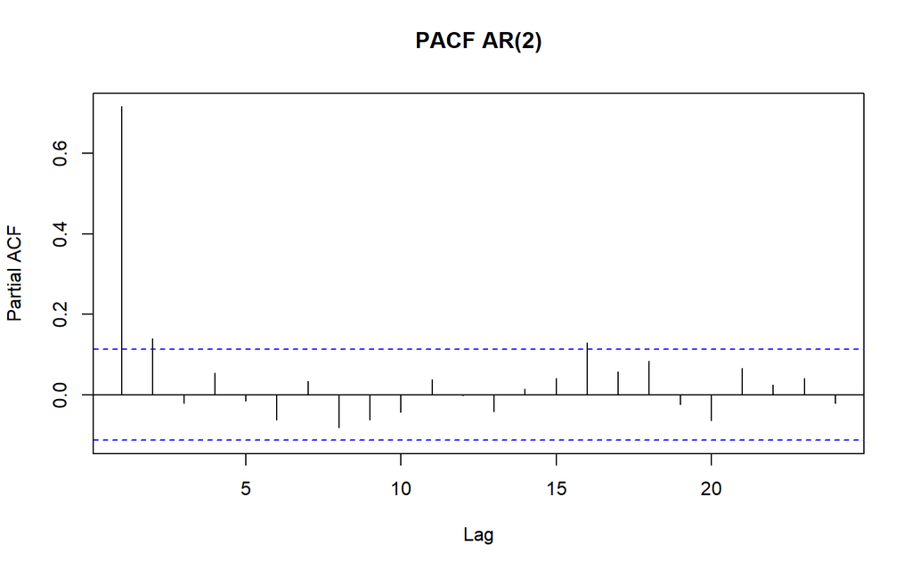

```r
pacf(ar2,
     main = "PACF AR(2)")
```

Plot PACF AR(2) menunjukkan korelasi parsial yang kuat hingga lag ke-2, kemudian menurun dan mendekati nol pada lag berikutnya. Pola ini sesuai dengan karakteristik AR(2), yaitu PACF terputus setelah orde AR, yaitu pada lag ke-2.

## f. Plot EACF

```r
TSA::eacf(ar2)
```

```
## AR/MA
##   0 1 2 3 4 5 6 7 8 9 10 11 12 13
## 0 x x x x x x x o o o o  o  o  o
## 1 x o o o o o o o o o o  o  o  o
## 2 x o o o o o o o o o o  o  o  o
## 3 x x o o o o o o o o o  o  o  o
## 4 x x o o o o o o o o o  o  o  o
## 5 x x x x o o x o o o o  o  o  o
## 6 x x x x o o o o o o o  o  o  o
## 7 x x x o x x o o o o o  o  o  o
```

## g. Stasioneritas

> Data hasil pembangkitan AR(2) dapat dikatakan stasioner karena memenuhi kondisi stasioneritas proses AR(2) dan plot time series tidak menunjukkan tren yang sistematis. Nilai data tetap berfluktuasi di sekitar nilai tengah sehingga karakteristik deret relatif stabil sepanjang waktu.

## h. Scatterplot $Y_t$ dengan $Y_{t−1}$

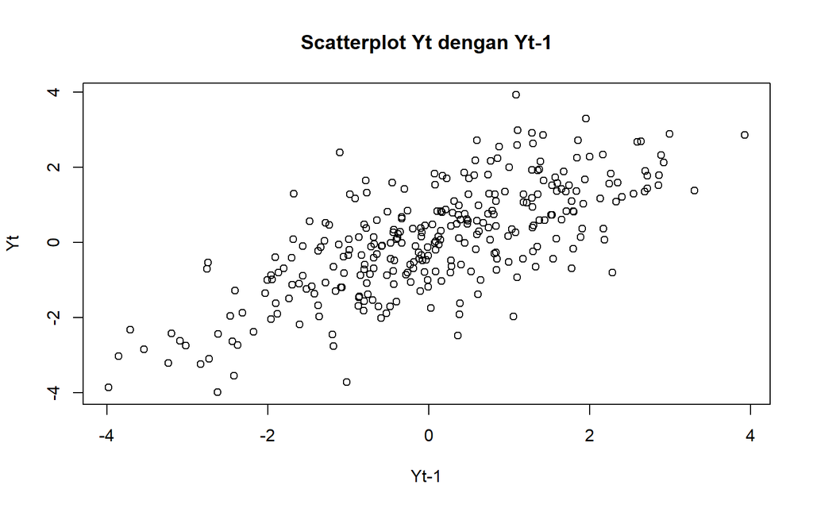

```r
# Yt
yt_ar2 <- ar2[-1]

# Yt-1
yt_1_ar2 <- ar2[-300]

plot(y = yt_ar2,
     x = yt_1_ar2,
     main = "Scatterplot Yt dengan Yt-1",
     xlab = "Yt-1",
     ylab = "Yt")
```

```r
cor(yt_ar2, yt_1_ar2)
```

```
## [1] 0.7173171
```

> Scatterplot menunjukkan hubungan positif antara $Y_t$ dan $Y_{t-1}$, dengan korelasi sebesar 0.7173. Hal ini menunjukkan bahwa nilai $Y_t$ cenderung meningkat ketika $Y_{t-1}$ meningkat. Pola tersebut sesuai dengan karakteristik model AR(2), di mana $Y_t$ dipengaruhi secara langsung oleh $Y_{t-1}$.

Korelasi antara $Y_t$ dengan $Y_{t−1}$ dari hasil simulasi mendekati perhitungan teoritis yaitu $\rho_1 = 0.625$.

$$\rho_1=\frac{\phi_1}{1-\phi_2}
=\frac{0.5}{1-0.2}
=0.625$$

## i. Scatterplot $Y_t$ dengan $Y_{t−2}$

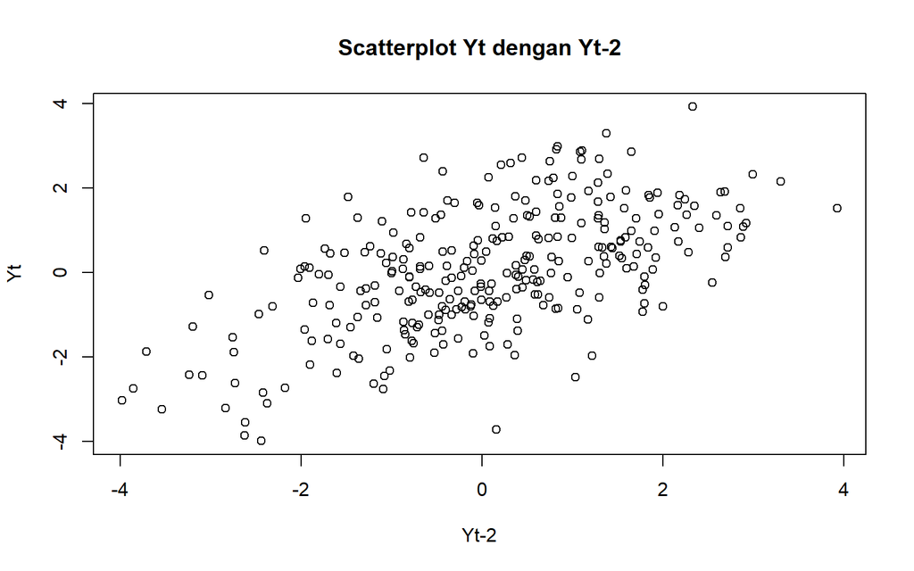

```r
# Yt
yt_ar2_2 <- ar2[-c(1,2)]

# Yt-2
yt_2_ar2 <- ar2[-c(299,300)]

plot(y = yt_ar2_2,
     x = yt_2_ar2,
     main = "Scatterplot Yt dengan Yt-2",
     xlab = "Yt-2",
     ylab = "Yt")
```

```r
cor(yt_ar2_2, yt_2_ar2)
```

```
## [1] 0.5836665
```

Korelasi antara $Y_t$ dengan $Y_{t−2}$ dari hasil simulasi mendekati perhitungan teoritis, yaitu $\rho_2 = 0.5125$.
$$\rho_2=\phi_1\rho_1+\phi_2
=(0.5)(0.625)+0.2
=0.5125$$

## j. Scatterplot $Y_t$ dengan $Y_{t-3}$

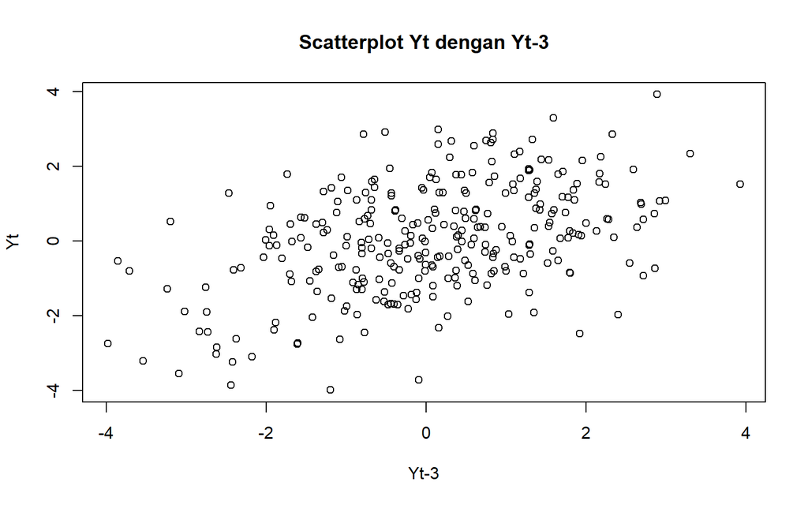

```r
# Yt
yt_ar2_3 <- ar2[-c(1,2,3)]

# Yt-3
yt_3_ar2 <- ar2[-c(298,299,300)]

plot(y = yt_ar2_3,
     x = yt_3_ar2,
     main = "Scatterplot Yt dengan Yt-3",
     xlab = "Yt-3",
     ylab = "Yt")
```

```r
cor(yt_ar2_3, yt_3_ar2)
```

```
## [1] 0.4522274
```

Korelasi antara $Y_t$ dengan $Y_{t−3}$ dari hasil simulasi mendekati perhitungan teoritis, yaitu$\rho_3 = 0.38125$.

$$\rho_3=\phi_1\rho_2+\phi_2\rho_1
=(0.5)(0.5125)+(0.2)(0.625)
=0.38125$$

# 3. ARMA(2,2) – Autoregressive Moving Average

## a. Pembangkitan Manual

```r
arma.sim <- function(n, macoef, arcoef){
  manum <- length(macoef)
  arnum <- length(arcoef)
  stopifnot(manum < n & arnum < n)

  wn <- rnorm(n, sd = 0.5)
  init <- max(manum, arnum)

  arma <- wn[1:init]
  for(i in {init+1}:n){
    mastart <- i - manum
    maend <- i-1
    arstart <- i - arnum
    arend <- i-1

    arma[i] <- sum(arcoef * arma[arstart:arend]) +
      sum(macoef * wn[mastart:maend]) + wn[i]
  }
  return(arma)
}
```

```r
set.seed(1234)

arma22 <- arma.sim(
  n = 300,
  macoef = c(0.4, 0.6),
  arcoef = c(0.5, 0.2)
)

arma22
```

```
##   [1] -0.603532875  0.138714621  0.110012698 -0.700670800 -0.357386542
##   [6] -0.509186896 -0.330258925 -0.665171971 -0.859327405 -1.228132352
##  [11] -1.293788271 -1.693182428 -1.768612042 -1.600637671 -0.860599659
##  [16] -0.726841534 -0.672359726 -1.128850371 -1.356096303 -0.061117444
##  [21] -0.065911313  0.234309569 -0.326755804  0.051296803 -0.450211407
##  [26] -0.904694521 -0.691872270 -1.219763842 -0.789603626 -1.445049581
##  [31] -0.416475197 -0.900116826 -0.665199397 -1.141677950 -1.667747448
##  [36] -2.077177748 -3.015433571 -3.199707932 -3.133111189 -2.815911770
##  [41] -1.603617849 -1.921331445 -1.644451095 -1.900205377 -1.954696488
##  [46] -2.179725769 -2.456374805 -2.733029109 -2.633766688 -2.549238484
##  [51] -2.983567280 -2.803550029 -3.142767487 -2.986891589 -2.776183351
##  [56] -2.018839814 -0.831496061 -0.955439425  0.293676366 -0.670786509
##  [61]  0.314814475  0.967480005  1.229538058  0.894200922  0.581964683
##  [66]  1.315827479  0.516448352  1.458951568  1.397423492  1.849631754
##  [71]  1.438939313  1.054231782  0.611791993  0.772566646  1.616725940
```

[output cut: 45 more lines]

Hasil pembangkitan manual menghasilkan 300 pengamatan ARMA(2,2). Nilai $Y_t$ dipengaruhi oleh dua komponen, yaitu nilai pengamatan sebelumnya melalui koefisien AR sebesar 0.5 dan 0.2 serta *white noise* sebelumnya melalui koefisien MA sebesar 0.4 dan 0.6. Dengan demikian, proses ARMA(2,2) menggabungkan ketergantungan terhadap pengamatan masa lalu dan *shock* pada periode sebelumnya.

## b. Dengan `arima.sim()`

```r
arma22.sim <- arima.sim(
  list(
    order = c(2,0,2),
    ar = c(0.5,0.2),
    ma = c(0.4,0.6)
  ),
  n = 300
)

arma22.sim
```

```
## Time Series:
## Start = 1
## End = 300
## Frequency = 1
##   [1] -2.0296272586  0.1804874357 -1.0857429326  0.2019685297  0.5101006237
##   [6]  0.3116647978  1.1440157679  0.4568971792 -0.3804875233 -0.8758133113
##  [11]  0.3166261152  0.2548874061  0.2592079202 -0.3290331722 -0.2948120396
##  [16]  0.8417548499  2.0860897066  2.3426969416  3.4797265438  1.9702862497
##  [21] -0.2703838028 -1.6091794075 -2.9699033669 -4.6121759676 -3.5735246545
##  [26] -4.6576056483 -3.2455887429 -4.7021051669 -3.2231197169 -1.3940059863
##  [31] -1.1346987187 -0.1752041013  1.0623014400  2.1418761113  4.7392121372
##  [36]  4.1182608009  4.0004548088  2.2502034531  3.0645576995  0.9645314951
##  [41]  1.7489003118  0.3724604884  2.9537132225  1.8162605804  1.0974763535
##  [46]  0.1760865572 -0.5446303408 -0.9525033432 -0.8123258962 -1.3227469686
##  [51] -1.5334325506 -0.9672480418 -1.3288936550 -2.5250400524 -5.1130294931
```

[output cut: 49 more lines]

Hasil `arima.sim()` menghasilkan 300 pengamatan dengan spesifikasi ARMA(2,2) yang sama seperti pembangkitan manual. Data menunjukkan fluktuasi yang dipengaruhi oleh kombinasi nilai pengamatan sebelumnya dan *white noise* sebelumnya.

## c. Plot Time Series

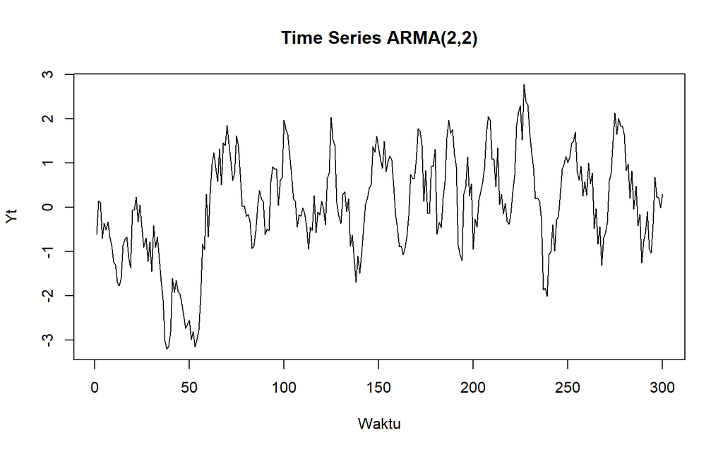

```r
plot.ts(arma22,
        main = "Time Series ARMA(2,2)",
        ylab = "Yt",
        xlab = "Waktu")
```

Plot time series ARMA(2,2) menunjukkan data yang berfluktuasi sepanjang waktu tanpa tren yang sistematis. Meskipun terdapat beberapa periode dengan nilai relatif tinggi atau rendah secara berurutan, pola tersebut kembali berfluktuasi sehingga tidak menunjukkan perubahan ragam yang sistematis. Hal ini mendukung karakteristik proses yang stasioner.

## d. Plot ACF

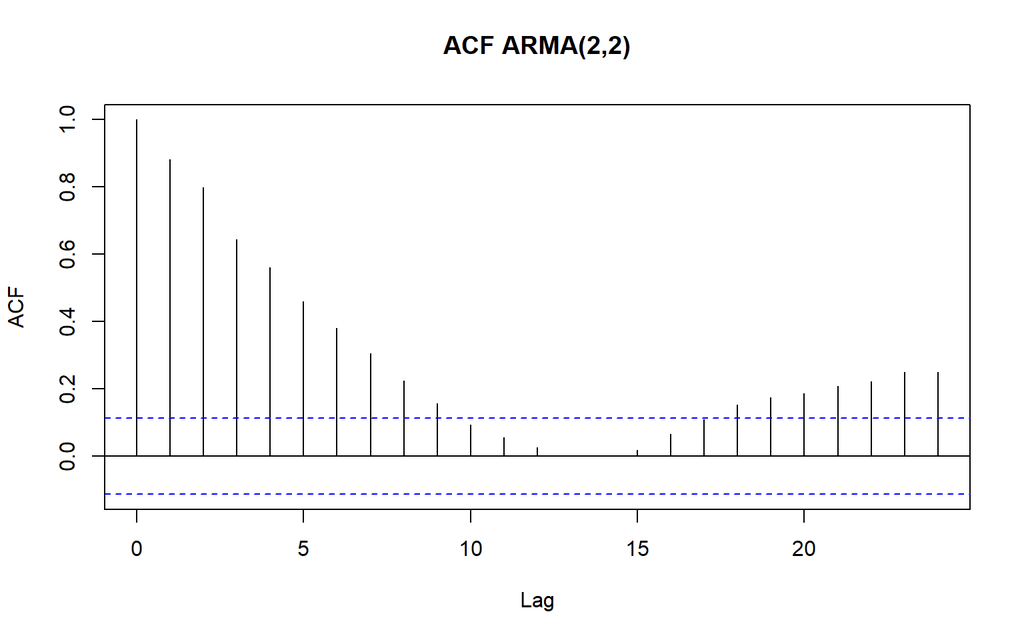

```r
acf(arma22,
    main = "ACF ARMA(2,2)")
```

Plot ACF ARMA(2,2) menunjukkan korelasi positif yang kuat pada beberapa lag awal dan kemudian menurun secara bertahap. Pola *tails off* terjadi karena adanya komponen AR, sehingga korelasi tidak langsung terputus setelah lag ke-2 seperti pada MA(2).

## e. Plot PACF

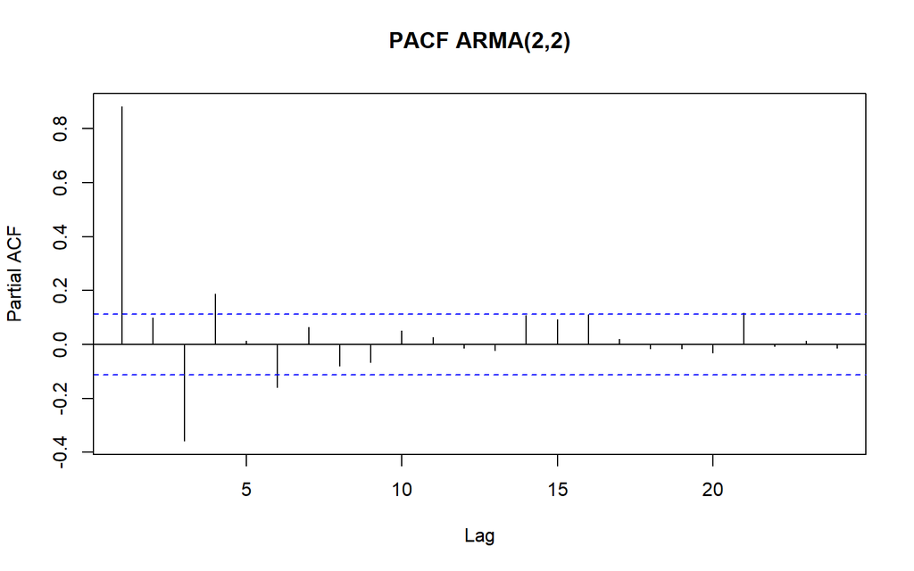

```r
pacf(arma22,
     main = "PACF ARMA(2,2)")
```

Plot PACF ARMA(2,2) juga menunjukkan pola peluruhan secara bertahap dan tidak terputus secara tegas setelah lag ke-2. Hal ini terjadi karena proses ARMA memiliki kombinasi komponen AR dan MA, sehingga pola ACF maupun PACF umumnya tidak menunjukkan *cut off* yang sederhana seperti pada AR atau MA murni.

## f. Plot EACF

```r
TSA::eacf(arma22)
```

```
## AR/MA
##   0 1 2 3 4 5 6 7 8 9 10 11 12 13
## 0 x x x x x x x x x o o  o  o  o
## 1 o x x x o o o o o o o  o  o  o
## 2 x x o x o o o o o o o  o  o  o
## 3 x x o o o o x o o o o  o  o  o
## 4 o x x o o o x o o o o  o  o  o
## 5 o x x x o o x o o o o  o  o  o
## 6 x x x x o o o o o o o  o  o  o
## 7 x x x x o x o o o o o  o  o  o
```

Hasil EACF digunakan untuk membantu mengidentifikasi orde AR dan MA pada proses ARMA. Pola yang diperoleh mendukung keberadaan komponen AR dan MA sehingga konsisten dengan model ARMA(2,2) yang digunakan dalam simulasi.

## g. Stasioneritas

> Data hasil pembangkitan ARMA(2,2) dapat dikatakan stasioner karena komponen AR memenuhi kondisi stasioneritas dan plot time series tidak menunjukkan tren maupun perubahan ragam yang sistematis sepanjang waktu.

## h. Scatterplot $Y_t$ dengan $Y_{t−1}$

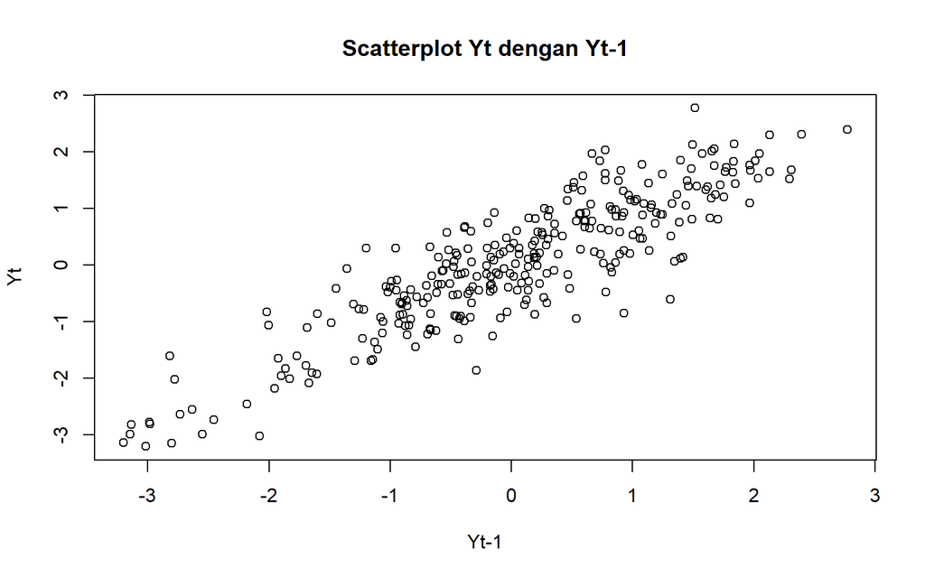

```r
# Yt
yt_arma22 <- arma22[-1]

# Yt-1
yt_1_arma22 <- arma22[-300]

plot(y = yt_arma22,
     x = yt_1_arma22,
     main = "Scatterplot Yt dengan Yt-1",
     xlab = "Yt-1",
     ylab = "Yt")
```

```r
cor(yt_arma22, yt_1_arma22)
```

```
## [1] 0.8822069
```

> Hubungan antara $Y_t$ dan $Y_{t-1}$ terlihat positif dan cukup kuat, dengan korelasi simulasi sebesar **0.8822**. Nilai ini juga dekat dengan korelasi teoritis **0.8592**, sehingga pola data hasil pembangkitan sudah mencerminkan ketergantungan positif pada periode sebelumnya.

Model ARMA(2,2) yang digunakan adalah:

$$Y_t=0.5Y_{t-1}+0.2Y_{t-2}
+e_t+0.4e_{t-1}+0.6e_{t-2}$$

1. Koefisien MA tak hingga dihitung terlebih dahulu, dengan:

$$\psi_0=1$$

$$\psi_1=\phi_1+\theta_1
=(0.5)+(0.4)=0.9$$

$$\psi_2=\phi_1\psi_1+\phi_2+\theta_2
=(0.5)(0.9)+(0.2)+(0.6)=1.25$$

2. Persamaan autokovarians untuk $k=0,1,2$ adalah:

$$\gamma_0-0.5\gamma_1-0.2\gamma_2=2.11\sigma_e^2$$

$$0.8\gamma_1-0.5\gamma_0=0.94\sigma_e^2$$

$$\gamma_2-0.5\gamma_1-0.2\gamma_0=0.6\sigma_e^2$$

3. Dengan $\sigma_e^2=1$, diperoleh:

$$\gamma_0=5.0171,\quad
\gamma_1=4.3107,\quad
\gamma_2=3.7588$$

Sehingga korelasi teoritis antara $Y_t$ dengan $Y_{t−1}$ adalah:

$$\rho_1=\frac{\gamma_1}{\gamma_0}
=\frac{4.3107}{5.0171}
=0.8592$$

## i. Scatterplot $Y_t$ dengan $Y_{t−2}$

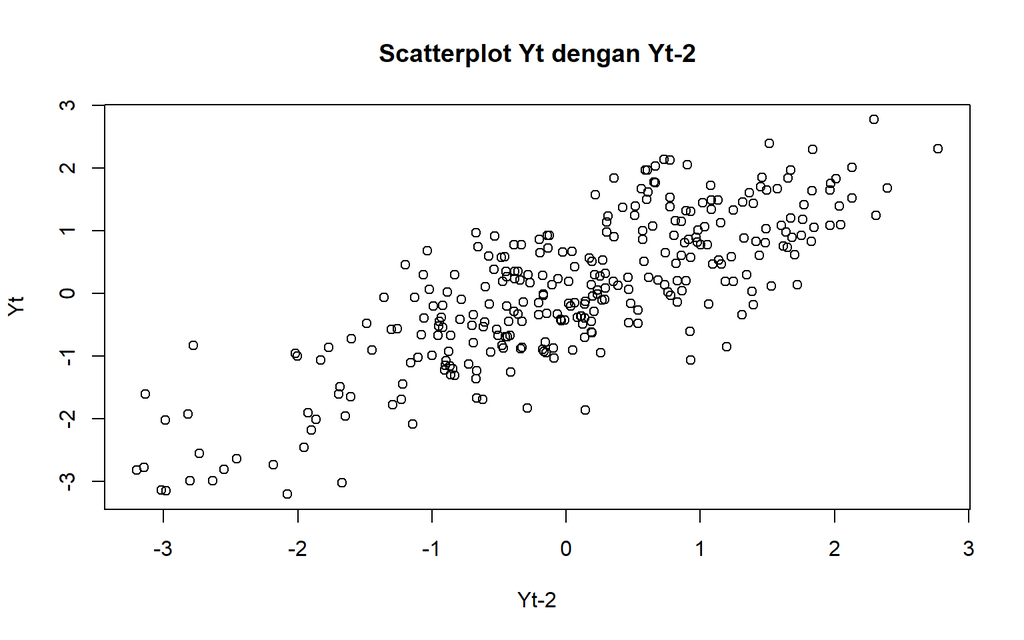

```r
# Yt
yt_arma22_2 <- arma22[-c(1,2)]

# Yt-2
yt_2_arma22 <- arma22[-c(299,300)]

plot(y = yt_arma22_2,
     x = yt_2_arma22,
     main = "Scatterplot Yt dengan Yt-2",
     xlab = "Yt-2",
     ylab = "Yt")
```

```r
cor(yt_arma22_2, yt_2_arma22)
```

```
## [1] 0.7999128
```

> Pada lag 2, hubungan positif masih terlihat dengan korelasi simulasi sebesar **0.7999**, sedangkan nilai teoritisnya sebesar **0.7492**. Korelasi yang masih tinggi menunjukkan bahwa nilai $Y_t$ tidak hanya berkaitan dengan satu periode sebelumnya, tetapi juga masih memiliki keterkaitan dengan dua periode sebelumnya.

Korelasi teoritis antara $Y_t$ dengan $Y_{t−2}$ adalah:

$$\rho_2=\frac{\gamma_2}{\gamma_0}
=\frac{3.7588}{5.0171}
=0.7492$$

## j. Scatterplot $Y_t$ dengan $Y_{t-3}$

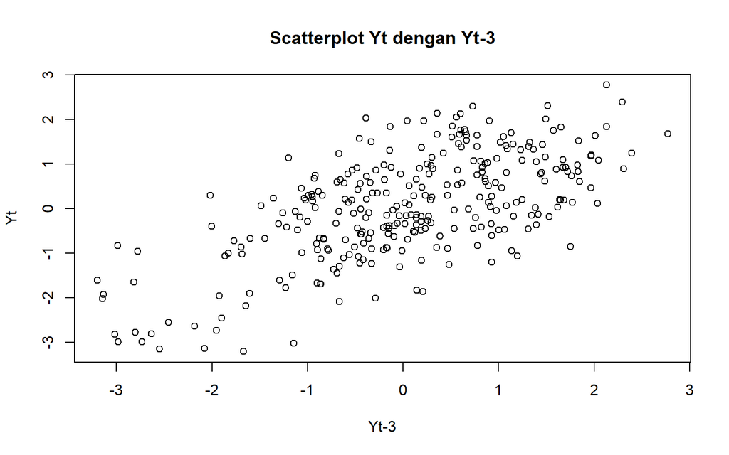

```r
# Yt
yt_arma22_3 <- arma22[-c(1,2,3)]

# Yt-3
yt_3_arma22 <- arma22[-c(298,299,300)]

plot(y = yt_arma22_3,
     x = yt_3_arma22,
     main = "Scatterplot Yt dengan Yt-3",
     xlab = "Yt-3",
     ylab = "Yt")
```

```r
cor(yt_arma22_3, yt_3_arma22)
```

```
## [1] 0.6438762
```

> Memasuki lag 3, korelasi simulasi turun menjadi **0.6439**, dengan nilai teoritis sebesar **0.5464**. Meskipun lebih rendah dibandingkan lag 1 dan lag 2, hubungan yang terbentuk tetap positif. Hal ini menunjukkan bahwa ketergantungan dalam proses ARMA(2,2) masih berlanjut pada lag yang lebih jauh.

Untuk menghitung korelasi teoritis lag 3 dan seterusnya digunakan hubungan AR:

$$\rho_k=\phi_1\rho_{k-1}+\phi_2\rho_{k-2}$$

Sehingga, korelasi teoritis antara $Y_t$ dengan $Y_{t−3}$ adalah:

$$\rho_3=(0.5)(0.7492)+(0.2)(0.8592)
=0.5464$$

# 4. Perbandingan Hasil

```r
hasil_korelasi <- data.frame(
  Model = rep(c("MA(2)", "AR(2)", "ARMA(2,2)"), each = 3),
  Lag = rep(1:3, 3),
  Simulasi = c(
    cor(ma2[-c(1)], ma2[-length(ma2)]),
    cor(ma2[-c(1,2)], ma2[-c(length(ma2)-1, length(ma2))]),
    cor(ma2[-c(1,2,3)], ma2[-c(length(ma2)-2, length(ma2)-1, length(ma2))]),

    cor(ar2[-c(1)], ar2[-length(ar2)]),
    cor(ar2[-c(1,2)], ar2[-c(length(ar2)-1, length(ar2))]),
    cor(ar2[-c(1,2,3)], ar2[-c(length(ar2)-2, length(ar2)-1, length(ar2))]),

    cor(arma22[-c(1)], arma22[-length(arma22)]),
    cor(arma22[-c(1,2)], arma22[-c(length(arma22)-1, length(arma22))]),
    cor(arma22[-c(1,2,3)], arma22[-c(length(arma22)-2, length(arma22)-1, length(arma22))])
  ),
  Teoritis = c(
    0.4211, 0.3947, 0,
    0.6250, 0.5125, 0.3813,
    0.8592, 0.7492, 0.5464
  )
)

hasil_korelasi
```

```
##       Model Lag   Simulasi Teoritis
## 1     MA(2)   1 0.52962901   0.4211
## 2     MA(2)   2 0.42848395   0.3947
## 3     MA(2)   3 0.07798615   0.0000
## 4     AR(2)   1 0.71731712   0.6250
## 5     AR(2)   2 0.58366647   0.5125
## 6     AR(2)   3 0.45222735   0.3813
## 7 ARMA(2,2)   1 0.88220686   0.8592
## 8 ARMA(2,2)   2 0.79991277   0.7492
## 9 ARMA(2,2)   3 0.64387622   0.5464
```

Hasil perbandingan menunjukkan bahwa korelasi simulasi pada ketiga model secara umum mendekati nilai teoritis. MA(2) memiliki korelasi yang mendekati nol setelah lag ke-2, sedangkan AR(2) dan ARMA(2,2) tetap menunjukkan korelasi positif hingga lag ke-3 dengan kecenderungan menurun. Perbedaan nilai simulasi dan teoritis disebabkan oleh variasi pada korelasi sampel hasil pembangkitan. Pola tersebut sesuai dengan karakteristik masing-masing model, yaitu *cut off* pada MA(2) dan *tails off* pada model yang memiliki komponen AR.